# Corona - Fallzahlenauswertung

### Datenquelle, Abrufzeitpunkt

[Link zur Datenbeschreibung des RKI](https://www.arcgis.com/home/item.html?id=dd4580c810204019a7b8eb3e0b329dd6)

| Amtliche RKI-Corona-Daten für Land-/Stadtkreis | Abrufzeitpunkt |
| --- | --- |
| Passau, kreisfreie Stadt | Mittwoch, 21.04.2021, 07:14:22 |

### Inzidenzrelevanter Zeitraum

| von - bis | nicht mehr in der Inzidenzzahl |
| --- | --- |
| Mi, 14.04.2021 - Di, 20.04.2021 | Di, 13.04.2021 und älter |

### Veränderungen zum Vortag

```
##  Meldedatum Art Inzidenzrelevant Fallzahl A15-A34 A35-A59 A60-A79
##  2021-04-19 Neu               Ja        1       0       1       0
##  2021-04-20 Neu               Ja       15       4      10       1
```

### Altersstruktur der aktuellen 7-Tage-Inzidenzfälle

```
##  A05-A14 A15-A34 A35-A59 A60-A79
##        8      21      25       3
```

### Neu gemeldete Fälle je Tag seit 01.01.2021

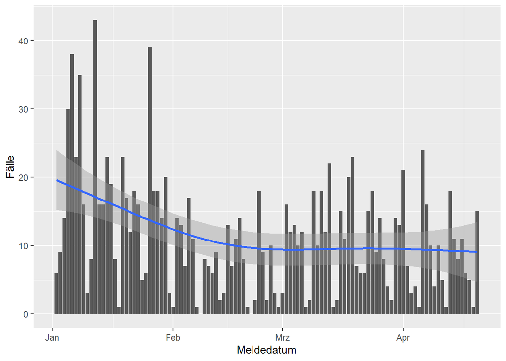

### Wochenübersicht

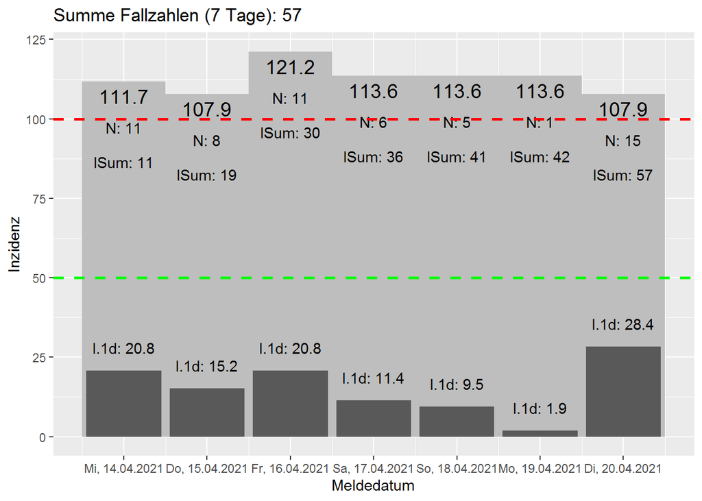

Erläuterung der Zahlenangaben:  
**N**: Anzahl der neu und nachträglich gemeldeten abzüglich der gestrichenen Fälle des jeweiligen Tages  
**I.1d** (“1-Tages-Inzidenz”): Höhe des Beitrags, den dieser Tag zur Wocheninzidenz leistet  
**lSum**: Aggregierte Summe der Fallzahlen über den Verlauf der beobachteten Woche. Der erste Tag entspricht diesem einzelnen Tag (und fällt als nächstes aus der Inzidenz), der letzte Tag entspricht der Wochen-Inzidenz.

### Über-/Unterschreitungen der geltenden Grenzwerte

```
##  Grenzwert bei_Fallzahl Abweichung
##         50           26        +31
##        100           52         +5
```

### Gesicherter Ausblick (absehbare Streichungen)

Aktuelle Inzidenz: 107.9, basierend auf den insgesamt 57 Fällen der letzten Woche.

[output not shown]

Die Fallzahlen der nächsten Tage sowie eventuelle Nachmeldungen sind dabei nicht vorhersehbar. Der maximale Rückgang wird nur erreicht, wenn bis zu diesem Tag per Saldo kein neuer Fall erfasst wird.

### Ungesicherter Ausblick

Fallzahlen gehen je nach Wochentag in unterschiedlicher Höhe ein. Basierend auf den letzten 3 Wochen bzw. 21 Tagen ergibt sich folgende Verteilung:

```
##   Wochentag Mittelwert
##     Sonntag       4.67
##      Montag       1.00
##    Dienstag      19.00
##    Mittwoch      13.33
##  Donnerstag      13.00
##     Freitag       7.33
##     Samstag       6.33
```

…auf der Grundlage folgender Fallzahlen der letzten 3 Wochen:

```
##  Meldedatum AnzahlFall  Wochentag
##  2021-03-31         13   Mittwoch
##  2021-04-01         21 Donnerstag
##  2021-04-02          7    Freitag
##  2021-04-03          3    Samstag
##  2021-04-04          4    Sonntag
##  2021-04-05          1     Montag
##  2021-04-06         24   Dienstag
##  2021-04-07         16   Mittwoch
##  2021-04-08         10 Donnerstag
##  2021-04-09          4    Freitag
##  2021-04-10         10    Samstag
##  2021-04-11          5    Sonntag
##  2021-04-12          1     Montag
##  2021-04-13         18   Dienstag
##  2021-04-14         11   Mittwoch
##  2021-04-15          8 Donnerstag
##  2021-04-16         11    Freitag
##  2021-04-17          6    Samstag
##  2021-04-18          5    Sonntag
##  2021-04-19          1     Montag
##  2021-04-20         15   Dienstag
```

### Blick in die Kristallkugel

Hier werden drei verschiedene Szenarien dargestellt:  
* Optimistische Variante 0 (Grün): Es treten keine Fälle mehr auf, somit dauert es noch 7 Tage, bis alle Inzidenzfälle abgeschmolzen sind.  
* Realistische Variante 1 (schwarz): Täglich kommen die durchschnittlichen Fälle für den jeweiligen Wochentag hinzu, was dem Abschmelzen aus Variante 0 entgegenwirkt.  
* Pessimistische Variante 2 (Rot): Wie Variante 1, nur kommt täglich der DOPPELTE Durchschnitt für den jeweiligen Wochentag hinzu. Dieser Zuwachs stellt keineswegs das obere Limit des möglichen dar.

**Bitte beachten: Im Folgenden stellt die Zeitachse das Veröffentlichungsdatum dar, nicht das Meldedatum, und ist somit um einen Tag verschoben!**

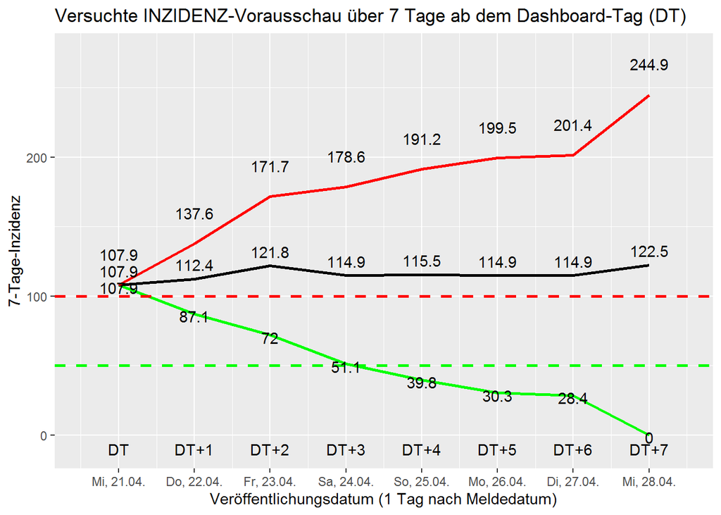

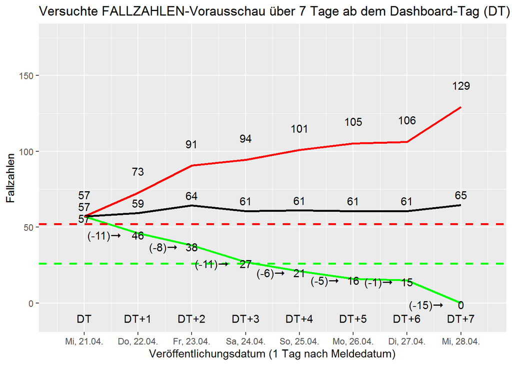